# Veri Görselleştirme

PhD. Burcu MESTAV

2020-11-03

# 1. Veri görselleştirme

`Bir resim bin sözcüğe bedeldir` denir. Ve bugün, büyük veri çağında işletmeler çeşitli veri türlerinden, şirket içi ve bulut tabanlı kaynaklardan akan bilgi seline kapılmışken bu eski deyiş, hiç olmadığı kadar anlamlı hale geldi.

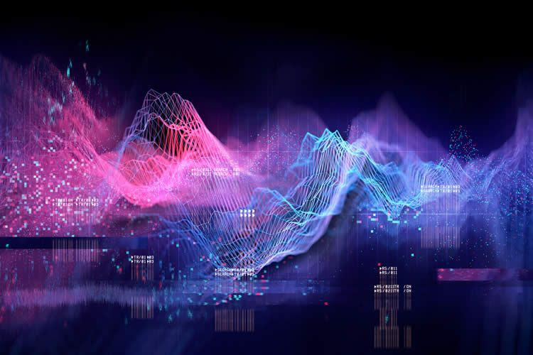

image: https://www.monitera.com/tr/blog/en-iyi-veri-gorsellestirme-araclari

Veri görselleştirme; soyut bilgilerin grafik olarak temsil edilmesi anlamına gelir. Veri görselleştirme, geleneksel raporlarda, tablolarda veya elektronik tablolarda fark edemeyebileceğimiz modelleri, trendleri ve korelasyonları belirlememizi sağlar.

Neyin önemli olup neyin olmadığını anlamak için bilgi taramak giderek daha zor hale geliyor. Görseller, analizi daha kolay ve daha hızlı hale getirirken, önemli konuları bir bakışta görme becerisi sunar. Dahası, çoğu insan görsellere metinden çok daha iyi tepki verir. Beyne gönderilen bilgilerin yüzde 90’ı görseldir ve beyin görselleri metne kıyasla 60.000 kat daha hızlı işler. Bu noktalar, bilgiyi analiz etmek ve iletmek için veri görselleştirmesi kullanmanın önemini güçlü bir biçimde ortaya koyuyor.

İyi veri görselleştirme verileri analiz etmek ve bu verilere dayalı kararlar almak için esastır. İnsanların yapılar ile ilişkileri hızla ve kolayca görüp anlamalarını, yalnızca ham sayılardan oluşan tablolarda fark edilemeyen trendleri tespit etmelerini sağlar. Ve birçok durumda, grafiklerde sunulanları yorumlamak için özel eğitim gerekmez, evrensel anlayış sağlanır.

İyi tasarlanmış bir grafik bilgi sağlamakla kalmaz, güçlü bir sunumla bu bilgilerin etkisini artırır, dikkat çeker ve insanların ilgisini hiçbir elektronik tablonun yapamayacağı ölçüde güçlü tutar.

iyi bir veribilimci görselleştimede kullanacağı grafik için veri türünü ve amacını her zaman dikkate almalıdır. Bazı bilgiler grafik için diğerine göre daha uygundur: örneğin, pasta grafik yerine çubuk grafik. Ancak çoğu araçta kullanıcı, çizgi ve çubuk grafikler gibi genel grafiklerden zaman çizelgelerine, haritalara, grafiklere, histogramlara ve özel tasarımlara kadar geniş görsel analitik seçeneklerine sahiptir.

Veri görselleştirme (VeriGör), istatistiğin ve tasarımın anlamlı bir şekilde birleşimi olarak tanımlanabilir. VeriGör, hem işin istatistik yanı için eldeki veriyi grafiksel olarak tutarlı ve hatasız olarak betimleyebilmeli, hem de tasarım yanı için tasarım ilkelerine uygun olarak veriyi sadece güzelleştirmeyi değil aynı zamanda anlaşılır ve anlamı bir şekilde sunmayı amaçlar. Böylece bir görsel iletişim aracı olarak VeriGör, analizleri daha kolay anlaşılır hale getirir ve paylaşımını kolaylaştırır.

VeriGör temel olarak “kesifsel” ve “açıklayıcı” olarak ikiye ayrılır. Kesifsel VeriGör materyalleri kolay oluşturulur, veri açısından zengindir. Bir başka deyişle Kesifsel VeriGör grafiksel veri analizi yapmayı hedefler. Açıklayıcı VeriGör ise daha fazla emek ister, verinin inceltilmesini gerektirir ve geniş kitleleri hedefler. Dolayısıyla Açıklayıcı VeriGör iletişimin bir parçası olarak tasarlanır. Veri bilimcisinin işi her iki türü beraber ve etkin olarak kullanmaktır. Unutmayın, iyi bir görsel tasarım hedeflenen kitleyi düşünmek ile baslar.

Eklediğim [**Linkte**](https://www.newslabturkey.org/turkiye-ve-dunyadan-orneklerle-veri-gorsellestirme-hatalari/) Türkiye ve dünyadan örneklerle veri görselleştirme hataları hakkında görsellerle genel bir bilgi edinebilirsiniz.

Bu dersteki grafikleri oluşturmak için, öncelikle bazı R paketlerini yüklemeniz gerekecektir. Gerekli tüm paketleri kurmak için, RStudio konsol penceresinde aşağıdaki **kodu** çalıştırmanız yeterli.

```r
pkgs <- c("ggplot2", "dplyr", "tidyr",
          "mosaicData", "carData",
          "VIM", "scales", "treemapify",
          "gapminder", "ggmap", "choroplethr",
          "choroplethrMaps", "CGPfunctions",
          "ggcorrplot", "visreg",
          "gcookbook", "forcats",
          "survival", "tibble","survminer",
          "ggalluvial", "ggridges",
          "GGally", "MASS","superheat",
          "waterfalls", "factoextra",
          "networkD3", "ggthemes",
          "hrbrthemes", "ggpol",
          "ggbeeswarm")
install.packages(pkgs)
```

Belirli bir paketi ilk ihtiyaç duyduğunuzda `library(kütüphane_adı)` fonkiyonu ile aktif hale getirebilirsiniz. Bir kütüphane yüklendiğinde inaktiftir. Bahsettiğim fonksiyonu kullanarak aktif hale getirin.

Örneğin; `library(gapminder)` yazın konsola ve **run** ’a basın

Eğer;

```
Error in library(gapminder) : there is no package called ‘gapminder’
```

Kütphanede hata (gapminder): “gapminder” adında bir paket yok

Yani paketin hiç kurulmadığını ifade etmekte olup aşağıdaki kodu çalıştırın.

```
install.packages ("gapminder")

library(gapminder)
```

o noktadan itibaren çalışacaktır.

Grafiklere geçmeden önce veri setlerinizi yüklemeniz gerekmektedir. Bu çalışma için **R** programının base’inde bulunan hazır datasetlerini kullanacağız. Hazır datasetlere ulaşmak için console’a `data()` yazın ve **run** ’a basın. Gelen listeden bir tanesi seçin ve r ortamına aşağıdaki kodla yükleyin

```
# Loading

data(mtcars)

# Print the first 6 rows

head(mtcars, 6)
```

Farklı datasetler ile bu çalışmayı yenilemek isterseniz [**datasetlist**](https://vincentarelbundock.github.io/Rdatasets/datasets.html) ’den indirebilir ve veri import prosedürü ile R ortamına aktabilirsiniz. Ayıca [**dataset package**](https://stat.ethz.ch/R-manual/R-devel/library/datasets/html/00Index.html) den de yararlanabilirsiniz. Bunun dışında kendi veri setlerinizi de yine aynı prosedürle aktarabilirsiniz.

## 1.1. ggplot2 paketi

`ggplot2` paketindeki işlevler, katmanlar halinde bir grafik oluşturur. Basit bir grafikle başlayıp her seferinde bir tane olmak üzere ek öğeler ekleyerek karmaşık bir grafik oluşturacağız.

Örnek, ücretler (wage) ve deneyim (expr) arasındaki ilişkiyi araştırmak için 1985 Nüfus Araştırmasından elde edilen verileri kullanacağız.

```r
#load data
data(CPS85 , package = "mosaicData")
library(tidyverse)
glimpse(CPS85)
```

```
## Rows: 534
## Columns: 11
## $ wage     <dbl> 9.00, 5.50, 3.80, 10.50, 15.00, 9.00, 9.57, 15.00, 11.00, 5.…
## $ educ     <int> 10, 12, 12, 12, 12, 16, 12, 14, 8, 12, 17, 17, 14, 14, 12, 1…
## $ race     <fct> W, W, W, W, W, W, W, W, W, W, W, W, W, W, W, W, W, NW, NW, W…
## $ sex      <fct> M, M, F, F, M, F, F, M, M, F, M, M, M, M, M, M, M, M, M, M, …
## $ hispanic <fct> NH, NH, NH, NH, NH, NH, NH, NH, NH, NH, Hisp, NH, Hisp, NH, …
## $ south    <fct> NS, NS, NS, NS, NS, NS, NS, NS, NS, NS, NS, NS, NS, NS, NS, …
## $ married  <fct> Married, Married, Single, Married, Married, Married, Married…
## $ exper    <int> 27, 20, 4, 29, 40, 27, 5, 22, 42, 14, 18, 3, 4, 14, 35, 0, 7…
## $ union    <fct> Not, Not, Not, Not, Union, Not, Union, Not, Not, Not, Not, N…
## $ age      <int> 43, 38, 22, 47, 58, 49, 23, 42, 56, 32, 41, 26, 24, 34, 53, …
## $ sector   <fct> const, sales, sales, clerical, const, clerical, service, sal…
```

Bir `ggplot2` grafiği oluştururken, yalnızca aşağıda açıklanan ilk iki işlev gereklidir. Diğer işlevler isteğe bağlıdır ve herhangi bir sırada eklenebilir.

### 1.1.1. ggplot işlevi

Bir grafik oluşturmanın ilk işlevi `ggplot()` işlevidir. Değişkenlerin grafiğin görsel özellikleriyle eşlenmesini çizilecek verileri içeren veri çerçevesini belirtir. Eksenler `aes` işlevinin içine yerleştirilir (aes, estetiği ifade eder).

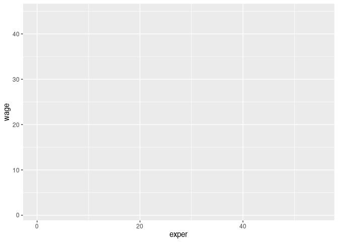

```r
# specify dataset and mapping
library(ggplot2)
ggplot(data = CPS85,
       mapping = aes(x = exper, y = wage))
```

Grafik neden boş? Biz bu aşamada sadece *Deneyim* değişkenini x eksenine yerleşmesi gerektiğini ve *ücretin* y eksenine yerleşmesi gerektiğini belirttik, ancak grafiğe ne koymak istediğimizi henüz belirtmedik.

### 1.1.2. Geomlar

Bir grafik üzerine yerleştirilebilen geometrik nesnelerdir (noktalar, çizgiler, çubuklar vb.). `Geom_` ile başlayan işlevler kullanılarak eklenirler. Bu örnekte, `geom_point` işlevini kullanarak noktalar ekleyerek bir saçılım (scatter plot) grafiği oluşturacağız.

`ggplot2` grafiklerinde fonksiyonlar, çizim oluşturmak için `+` işareti kullanılarak birbirine zincirlenir.

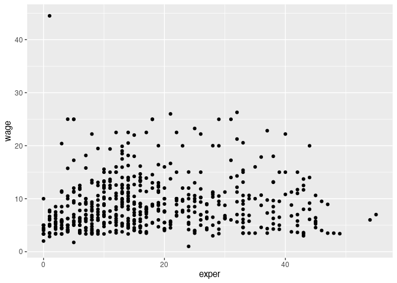

```r
# add points
ggplot(data = CPS85,
       mapping = aes(x = exper, y = wage)) +
  geom_point()
```

Grafik, bir aykırı değer olduğunu gösterir. Bir bireyin diğerlerinden çok daha yüksek bir ücreti vardır. Devam etmeden önce bu vakayı sileceğiz.

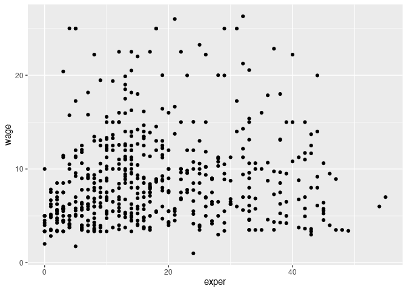

```r
# delete outlier
library(dplyr)
plotdata <- filter(CPS85, wage < 40)

# redraw scatterplot
ggplot(data = plotdata,
       mapping = aes(x = exper, y = wage)) +
  geom_point()
```

Bir `geom_` fonksiyonunda bir dizi parametre (seçenekler) belirtilebilir. Geom_point işlevi için seçenekler arasında `color`, `size` ve `alpha` bulunur. Bunlar sırasıyla nokta rengini, boyutunu ve şeffaflığını kontrol eder. Şeffaflık 0 (tamamen şeffaf) ile 1 (tamamen opak) arasında değişir. Bir dereceye kadar şeffaflık eklemek, çakışan noktaları görselleştirilmesine yardımcı olabilir.

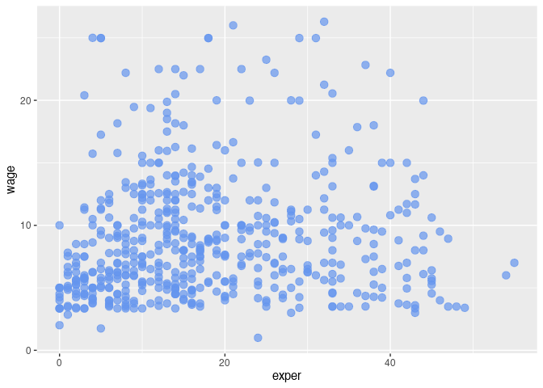

```r
# make points blue, larger, and semi-transparent
ggplot(data = plotdata,
       mapping = aes(x = exper, y = wage)) +
  geom_point(color = "cornflowerblue",
             alpha = .7,
             size = 3)
```

Ardından, uygun `line` ekleyelim. Bunu `geom_smooth` fonksiyonu ile yapabiliriz. Seçenekler, çizgi türünü (doğrusal, ikinci dereceden, parametrik olmayan), çizginin kalınlığını, çizginin rengini ve bir güven aralığının olup olmadığını kontrol eder. Burada doğrusal bir regresyon (yöntem = lm) çizgisi talep ediyoruz (burada lm, doğrusal model anlamına gelir).

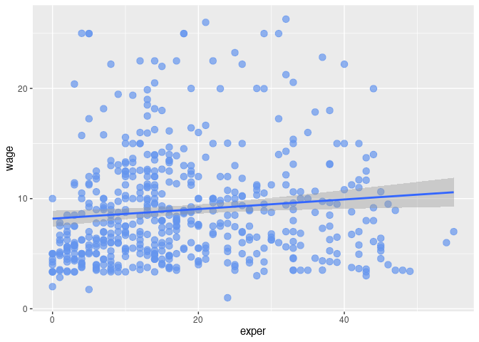

```r
# add a line of best fit.
ggplot(data = plotdata,
       mapping = aes(x = exper, y = wage)) +
  geom_point(color = "cornflowerblue",
             alpha = .7,
             size = 3) +
  geom_smooth(method = "lm")
```

### 1.1.3. Gruplama

Değişkenleri x ve y eksenlerine yerleştirmenin yanı sıra, değişkenler geometrik nesnelerin rengi, şekli, boyutu, şeffaflığı ve diğer görsel özellikleriyle eşlenebilir. Bu, gözlem gruplarının tek bir grafikte üst üste bindirilmesine izin verir.

Hikayeye cinsiyet (sex) değişkenini ekleyelim ve onu renkle temsil edelim.

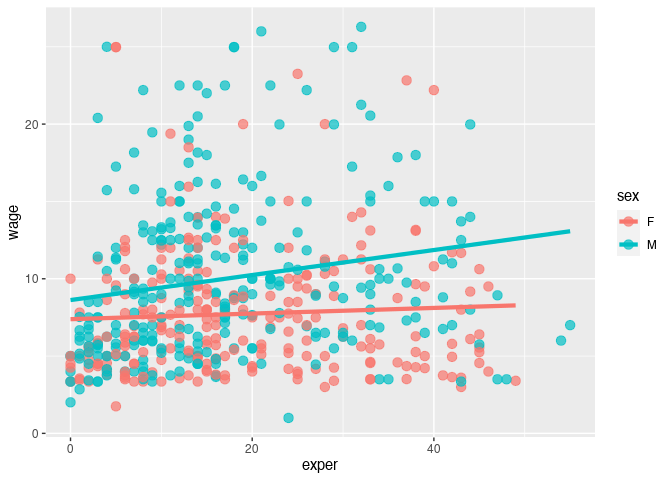

```r
# indicate sex using color
ggplot(data = plotdata,
       mapping = aes(x = exper,
                     y = wage,
                     color = sex)) +
  geom_point(alpha = .7,
             size = 3) +
  geom_smooth(method = "lm",
              se = FALSE,
              size = 1.5)
```

`color = sex` seçeneği `aes` işlevine yerleştirilmiştir, çünkü bir değişkeni bir estetiğe eşleştiriyoruz. Güven aralıklarını göstermemek için `geom_smooth` seçeneği `(se = FALSE)` eklendi.

Görünüşe göre erkekler kadınlardan daha fazla para kazanma eğilimindedir. Ek olarak, erkekler için deneyim ve ücretler arasında kadınlardan daha güçlü bir ilişki olabilir.

### 1.1.4. Ölçekler

Ölçekler, değişkenlerin grafiğin görsel özellikleriyle nasıl eşlendiğini kontrol eder. Ölçek fonksiyonları (`scale_` ile başlayan) bu eşlemeyi değiştirmenize izin verir. Bir sonraki grafikte, x ve y ekseni ölçeklemesini ve kullanılan renkleri değiştireceğiz.

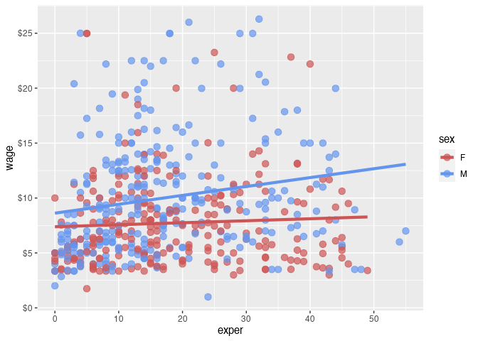

```r
# modify the x and y axes and specify the colors to be used
ggplot(data = plotdata,
       mapping = aes(x = exper,
                     y = wage,
                     color = sex)) +
  geom_point(alpha = .7,
             size = 3) +
  geom_smooth(method = "lm",
              se = FALSE,
              size = 1.5) +
  scale_x_continuous(breaks = seq(0, 60, 10)) +
  scale_y_continuous(breaks = seq(0, 30, 5),
                     label = scales::dollar) +
  scale_color_manual(values = c("indianred3",
                                "cornflowerblue"))
```

### 1.1.5. Fasetler

Fasetler, her seviye için belirli bir değişkeni (veya değişkenlerin kombinasyonunu) yeniden üretir. Özellikler, `facet_` ile başlayan işlevler kullanılarak oluşturulur. Burada fasetler, sektör (*Kategorik*) değişkeninin sekiz seviyesi ile tanımlanacaktır.

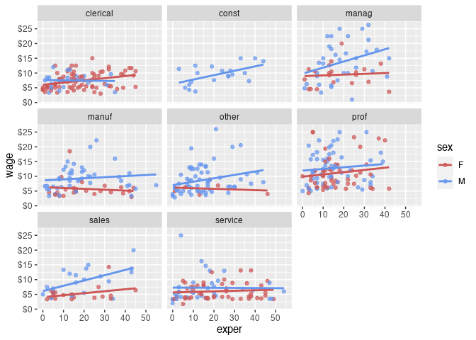

```r
# reproduce plot for each level of job sector
ggplot(data = plotdata,
       mapping = aes(x = exper,
                     y = wage,
                     color = sex)) +
  geom_point(alpha = .7) +
  geom_smooth(method = "lm",
              se = FALSE) +
  scale_x_continuous(breaks = seq(0, 60, 10)) +
  scale_y_continuous(breaks = seq(0, 30, 5),
                     label = scales::dollar) +
  scale_color_manual(values = c("indianred3",
                                "cornflowerblue")) +
  facet_wrap(~sector)
```

### 1.1.6. Etiketler

Grafiklerin yorumlanması kolay olmalıdır ve bilgilendirici etiketler bu hedefe ulaşmada kilit unsurdur. `labs` işlevi, eksenler ve göstergeler için özelleştirilmiş etiketler sağlar. Ek olarak, özel bir başlık (custom title), alt başlık (subtitle) ve ana başlık (caption) eklenebilir.

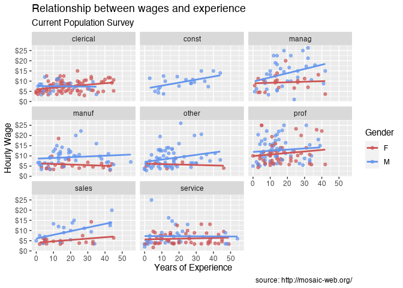

```r
# add informative labels
ggplot(data = plotdata,
       mapping = aes(x = exper,
                     y = wage,
                     color = sex)) +
  geom_point(alpha = .7) +
  geom_smooth(method = "lm",
              se = FALSE) +
  scale_x_continuous(breaks = seq(0, 60, 10)) +
  scale_y_continuous(breaks = seq(0, 30, 5),
                     label = scales::dollar) +
  scale_color_manual(values = c("indianred3",
                                "cornflowerblue")) +
  facet_wrap(~sector) +
  labs(title = "Relationship between wages and experience",
       subtitle = "Current Population Survey",
       caption = "source: http://mosaic-web.org/",
       x = " Years of Experience",
       y = "Hourly Wage",
       color = "Gender")
```

Artık bir izleyicinin veya okuyucunun deneyim ve ücret etiketlerinin ne anlama geldiğini veya verilerin nereden geldiğini tahmin etmesine gerek yok.

### 1.1.7. Temalar

Son olarak, temaları kullanarak grafiğin görünümünü ince ayarlayabiliriz. Tema işlevleri (`theme_` ile başlayan) arka plan renklerini, yazı tiplerini, kılavuz çizgilerini, gösterge yerleşimini ve grafiğin verilerle ilgili olmayan diğer özelliklerini kontrol eder. Daha temiz bir tema kullanalım.

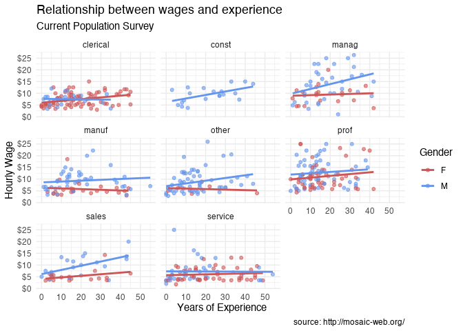

```r
# use a minimalist theme
ggplot(data = plotdata,
       mapping = aes(x = exper,
                     y = wage,
                     color = sex)) +
  geom_point(alpha = .6) +
  geom_smooth(method = "lm",
              se = FALSE) +
  scale_x_continuous(breaks = seq(0, 60, 10)) +
  scale_y_continuous(breaks = seq(0, 30, 5),
                     label = scales::dollar) +
  scale_color_manual(values = c("indianred3",
                                "cornflowerblue")) +
  facet_wrap(~sector) +
  labs(title = "Relationship between wages and experience",
       subtitle = "Current Population Survey",
       caption = "source: http://mosaic-web.org/",
       x = " Years of Experience",
       y = "Hourly Wage",
       color = "Gender") +
  theme_minimal()
```

## 1.2.Tek değişkenli grafikler

Tek değişkenli grafikler, verilerin tek bir değişkenden dağılımını gösterir. Değişken kategorik (ör. Irk, cinsiyet) veya nicel (ör. Yaş, kilo) olabilir.

### 1.2.1. Kategorik değişkenler için grafik

Tek bir kategorik değişkenin dağılımı tipik olarak bir çubuk grafik, bir pasta grafik veya (daha az yaygın olarak) bir ağaç haritası ile çizilir.

#### 1.2.1.1. Çubuk grafik

`Marriage` veri kümesi, Alabama, Mobile County’deki 98 kişinin evlilik kayıtlarını içerir. Aşağıda, düğün katılımcılarının ırklara göre dağılımını göstermek için bir çubuk grafik kullanılmıştır.

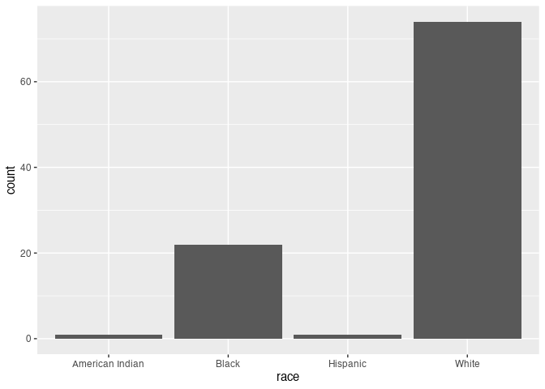

```r
library(ggplot2)
data(Marriage, package = "mosaicData")

# plot the distribution of race
ggplot(Marriage, aes(x = race)) +
  geom_bar()
```

Katılımcıların çoğunluğu beyaz, ardından çok az Hispanik veya Kızılderili olmak üzere siyahlar geliyor.

`geom_bar` işlevine seçenekler ekleyerek çubuk dolgusunu ve kenarlık renklerini, çizim etiketlerini ve başlığı değiştirebilirsiniz.

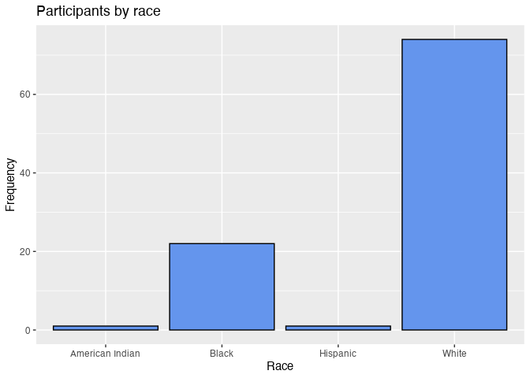

```r
# plot the distribution of race with modified colors and labels
ggplot(Marriage, aes(x = race)) +
  geom_bar(fill = "cornflowerblue",
           color="black") +
  labs(x = "Race",
       y = "Frequency",
       title = "Participants by race")
```

Çubuklar, sayılardan çok yüzdeleri temsil edebilir. Çubuk grafikler için, kod `aes (x = race)` aslında `aes (x = race, y = .. count ..)` için bir kısayoldur, burada `.. count ..` her kategori içindeki frekansı temsil eden özel bir değişkendir. Bunu, `y` değişkenini açıkça belirterek yüzdeleri hesaplamak için kullanabilirsiniz.

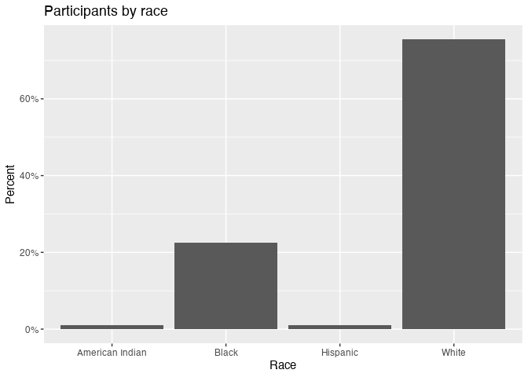

```r
# plot the distribution as percentages
ggplot(Marriage,
       aes(x = race,
           y = ..count.. / sum(..count..))) +
  geom_bar() +
  labs(x = "Race",
       y = "Percent",
       title  = "Participants by race") +
  scale_y_continuous(labels = scales::percent)
```

Yukarıdaki kodda, `scales` paketi *y*-ekseni etiketlerine % sembolleri eklemek için kullanılır.

Çubukları frekanslara göre sıralamak genellikle yararlıdır. Aşağıdaki kodda, frekanslar açıkça hesaplanmıştır. Ardından, kategorileri sıklığa göre sıralamak için `reorder` işlevi kullanılır. `stat="identity"` seçeneği, plotlama fonksiyonuna sayımları hesaplamamasını söyler, çünkü bunlar doğrudan sağlanır.

```r
# calculate number of participants in
# each race category
library(dplyr)
plotdata <- Marriage %>%
 count(race)
```

Bu yeni veri kümesi daha sonra grafiği oluşturmak için kullanılır.

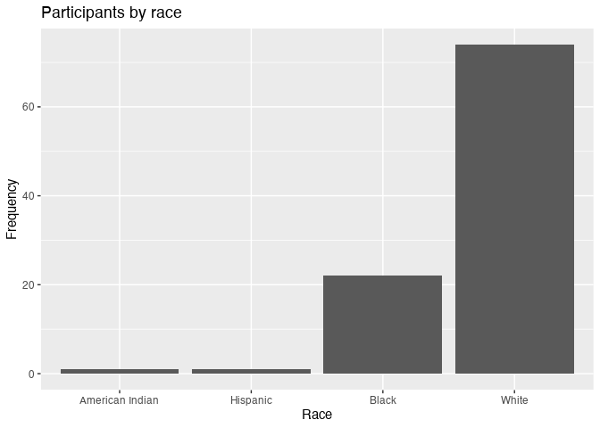

```r
# plot the bars in ascending order
ggplot(plotdata,
       aes(x = reorder(race, n),
           y = n)) +
  geom_bar(stat = "identity") +
  labs(x = "Race",
       y = "Frequency",
       title  = "Participants by race")
```

Grafik çubukları artan sırada sıralanmıştır. Azalan düzende sıralamak için reorder(race, -n) kullanın.

Son olarak, her çubuğu sayısal değeriyle etiketlemek isteyebilirsiniz. Burada `geom_text` etiketleri ekler ve `vjust`dikey hizalamayı kontrol eder.

```r
library(dplyr)
library(scales)
```

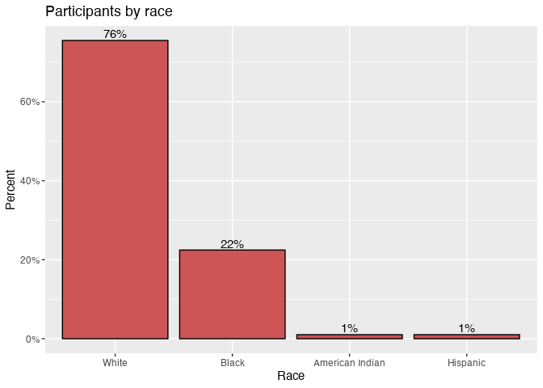

```r
plotdata <- Marriage %>%
  count(race) %>%
  mutate(pct = n / sum(n),
         pctlabel = paste0(round(pct*100), "%"))

# plot the bars as percentages,
# in decending order with bar labels
ggplot(plotdata,
       aes(x = reorder(race, -pct),
           y = pct)) +
  geom_bar(stat = "identity",
           fill = "indianred3",
           color = "black") +
  geom_text(aes(label = pctlabel),
            vjust = -0.25) +
  scale_y_continuous(labels = percent) +
  labs(x = "Race",
       y = "Percent",
       title  = "Participants by race")
```

#### 1.2.1.2. Pasta dilim grafik

Pasta dilim grafikler istatistiklerde tartışmalıdır. Amacınız kategorilerin sıklığını karşılaştırmaksa, çubuk grafiklerle daha iyi durumdasınızdır (insanlar çubukların uzunluğuna karar vermede pasta dilimlerinin hacminden daha iyidir). Hedefiniz her bir kategoriyi bütünle karşılaştırmaksa (örneğin, tüm katılımcılara kıyasla katılımcıların hangi kısmı İspanyol’dur) ve kategori sayısı azsa, pasta grafikler sizin için işe yarayabilir. R’de çekici bir pasta grafiği yapmak biraz daha fazla kod gerektirir.

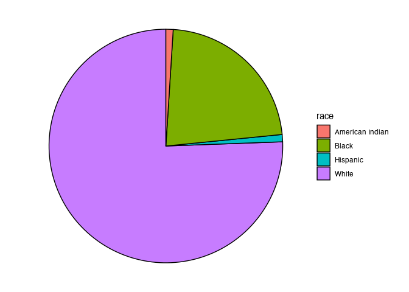

```r
# create a basic ggplot2 pie chart
 plotdata <- Marriage %>%
    count(race) %>%
    arrange(desc(race)) %>%
    mutate(prop = round(n * 100 / sum(n), 1),
           lab.ypos = cumsum(prop) - 0.5  *prop)

  ggplot(plotdata,
         aes(x = "",
             y = prop,
             fill = race)) +
    geom_bar(width = 1,
             stat = "identity",
             color = "black") +
    coord_polar("y",
                start = 0,
                direction = -1) +
    theme_void()
```

Şimdi açıklamayı kaldırıp biraz süsleyelim ve etiketler ekleyelim.

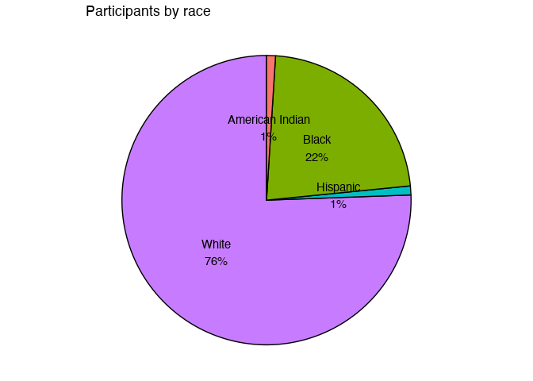

```r
# create a pie chart with slice labels
plotdata <- Marriage %>%
  count(race) %>%
  arrange(desc(race)) %>%
  mutate(prop = round(n*100/sum(n), 1),
         lab.ypos = cumsum(prop) - 0.5*prop)

plotdata$label <- paste0(plotdata$race, "\n",
                         round(plotdata$prop), "%")

ggplot(plotdata,
       aes(x = "",
           y = prop,
           fill = race)) +
  geom_bar(width = 1,
           stat = "identity",
           color = "black") +
  geom_text(aes(y = lab.ypos, label = label),
            color = "black") +
  coord_polar("y",
              start = 0,
              direction = -1) +
  theme_void() +
  theme(legend.position = "FALSE") +
  labs(title = "Participants by race")
```

### 1.2.2. Nicel değişkenler için grafikler

Tek bir nicel değişkenin dağılımı tipik olarak bir histogram, kernel density plot, ve ya dot plot ile çizilir.

#### 1.2.2.1. Histogram

`Marriage` veri kümesi kullanarak, düğün katılımcılarının yaşlarını planlayalım.

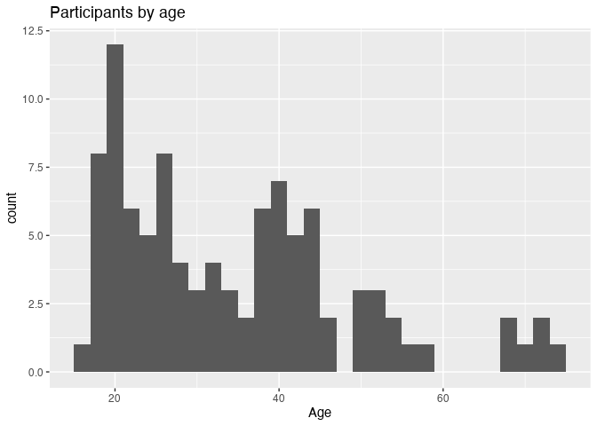

```r
library(ggplot2)

# plot the age distribution using a histogram
ggplot(Marriage, aes(x = age)) +
  geom_histogram() +
  labs(title = "Participants by age",
       x = "Age")
```

Çoğu katılımcı, 40’larında başka bir grupla 20’li yaşların başında ve altmışların sonlarında ve yetmişlerin başlarında çok daha küçük bir grupla birlikte görünmektedir. Bu, *multimodal* bir dağılım olacaktır.

Histogram renkleri iki seçenek kullanılarak değiştirilebilir

- `fill` - çubuklar için dolgu rengi
- `color` - çubukların etrafındaki kenarlık rengi

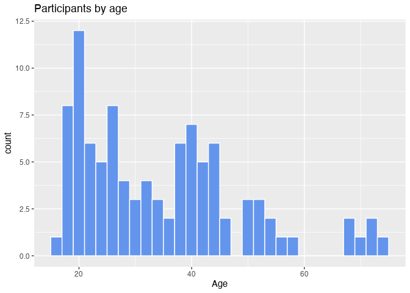

```r
# plot the histogram with blue bars and white borders
ggplot(Marriage, aes(x = age)) +
  geom_histogram(fill = "cornflowerblue",
                 color = "white") +
  labs(title="Participants by age",
       x = "Age")
```

En önemli histogram seçeneklerinden biri, sayısal değişkenin bölündüğü bölmelerin sayısını (yani grafikteki çubukların sayısını) kontrol eden `bins`. Varsayılan değer 30’dur, ancak dağıtımın şekli hakkında daha iyi bir izlenim elde etmek için daha küçük ve daha büyük sayıları denemek yararlıdır.

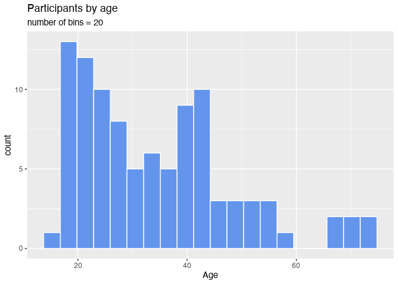

```r
# plot the histogram with 20 bins
ggplot(Marriage, aes(x = age)) +
  geom_histogram(fill = "cornflowerblue",
                 color = "white",
                 bins = 20) +
  labs(title="Participants by age",
       subtitle = "number of bins = 20",
       x = "Age")
```

Alternatif olarak, çubukların temsil ettiği bölmelerin bölme genişliğini de (`binwidth`) belirtebilirsiniz.

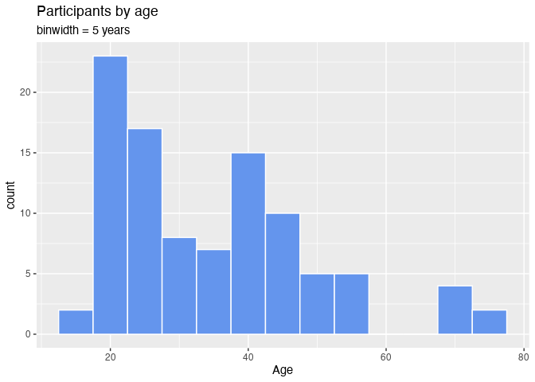

```r
# plot the histogram with a binwidth of 5
ggplot(Marriage, aes(x = age)) +
  geom_histogram(fill = "cornflowerblue",
                 color = "white",
                 binwidth = 5) +
  labs(title="Participants by age",
       subtitle = "binwidth = 5 years",
       x = "Age")
```

#### 1.2.2.2. Kernel Density grafiği

Histograma bir alternatif, Kernel density grafiğidir. Teknik olarak, Kernel density tahmini, sürekli bir rastgele değişkenin olasılık yoğunluk fonksiyonunu tahmin etmek için parametrik olmayan bir yöntemdir. (Ne ??) Temel olarak, eğrinin altındaki alanın bire eşit olduğu düzleştirilmiş bir histogram çizmeye çalışıyoruz.

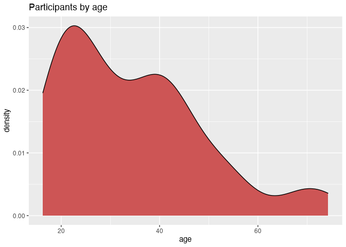

```r
# Create a kernel density plot of age
ggplot(Marriage, aes(x = age)) +
  geom_density(fill = "indianred3") +
  labs(title = "Participants by age")
```